# 1.0 Preprocess and align the E15.5 Xenium brain

This notebook prepares the Xenium E15.5 whole-brain dataset for 3D visualization with [Celldega](https://github.com/broadinstitute/celldega). The visualization notebooks that follow (`2.0` CellCloud, `2.1` NeighborhoodCloud, `3.0` composition + Landscape) read what is written here.

## The experiment

Whole-brain spatial transcriptomics of a **mouse embryo at E15.5** (female). The brain was cut into **44 coronal sections**, ordered from the front of the brain (slice 1, anterior) to the back (slice 44, posterior). The sections were placed on four Xenium slides and profiled with the **10x Xenium** platform and its **480-gene** panel, which reads out transcripts at subcellular resolution. Cells were segmented from the images, which gives each cell a position (in µm) and a gene-count vector.

Consecutive slices are stacked **100 µm** apart to rebuild the brain in 3D. After quality control the dataset holds about **3.8 million cells**.

## What this notebook does

1. **Load** the cells of all 44 slices (positions in µm, raw counts for the 480 genes).
2. **Cluster** all cells together with Leiden, so a cluster means the same thing in every slice.
3. **Drop** one slice (not shown) that does not align well and has poor clusters.
4. **Align** the remaining 43 slices in 3D with Celldega, in two stages:
   - *Centroids:* one landmark per (slice, cluster) at the cluster's centroid, then a rigid Procrustes fit chained out from the middle slice.
   - *Neighborhood overlap:* one alpha shape per (slice, cluster); each slice's rigid pose is refined to maximize the overlap of matching shapes in nearby slices.
5. **Write the DegaFiles** that the visualization notebooks load.

## Settings

```python
import shutil
import warnings

import anndata as ad
import h5py
import matplotlib.pyplot as plt
import numpy as np
import pandas as pd
import shapely
from anndata.io import read_elem
from sklearn.cluster import KMeans

import celldega as dega
from celldega.align.neighborhood import _load_slice_geometries

# The combined AnnData of all slices: raw counts, cell positions (um) and the Leiden labels. Point this at your copy.
SOURCE_H5AD = "/home/jovyan/workbench/data/processed_data/H5ADs/E155F/clustered_combined_adata.h5ad"

from pathlib import Path

import pyarrow as pa
import pyarrow.parquet as pq
import time

PROJECT_DIR = Path.cwd()
DATA_DIR = PROJECT_DIR / "data"
ALIGNMENT_DIR = DATA_DIR / "alignment"
DEGA_FILES_DIR = PROJECT_DIR / "DegaFiles"
CLUSTERED_H5AD = DATA_DIR / "xenium_E15.5_clustered.h5ad"      # working copy written in section 1

CLUSTER_KEY = "leiden_1.0"
Z_SPACING_UM = 100.0          # distance between consecutive slices in the 3D stack
ALPHA_UM = 100.0              # alpha-shape inv_alpha (circumradius threshold), um

# Where the DegaFiles are written
CELL_CLOUD_DIR = DEGA_FILES_DIR / "xenium_E15.5_cell_cloud"
NBHD_CLOUD_DIR = DEGA_FILES_DIR / "xenium_E15.5_neighborhood_cloud"

OUT_DIR = ALIGNMENT_DIR
LEIDEN_KEYS = ["leiden_0.5", "leiden_1.0", "leiden_1.5", "leiden_2.0", "leiden_2.5", "leiden_3"]

DROP_SLICES = [44]       # slice(s) left out of the 3D stack

# Stage 1, centroid Procrustes
PROCRUSTES_KW = dict(alignment_window=10, weight_by_adjacent_counts=False)
# Stage 2, neighborhood overlap
NBHD_KW = dict(alignment_window=4, n_sweeps=4, rotation_range=40.0, translation_range=0.20,
               n_rotation_grid=15, distance_weight="uniform")

for d in (DATA_DIR, OUT_DIR, DEGA_FILES_DIR):
    d.mkdir(parents=True, exist_ok=True)
dega.__version__
```

```
'0.26.1'
```

## Helpers

Two small functions, defined here so the notebook is self-contained.

- `side_view_coords` re-expresses the aligned cells for `CellCloud`. Its orbit camera always spins around the vertical (data-Z) axis, so the stack goes along data-X (anterior on the left, posterior on the right) and the dorsal-ventral axis along Z (dorsal up).
- `write_point_cloud_genes` writes the counts of every gene as one small file per gene, so that the viewer can color the 3D cloud by any gene.

```python
def side_view_coords(xy_um, stack_um, flip_dv=True):
    """Re-express aligned cells so CellCloud orbits *around* the brain.

    CellCloud uses deck.gl's ``OrbitView`` with ``orbitAxis="Z"``: left-right drag spins the
    scene around data-Z. The stacking axis therefore goes to data-X (anterior on the left),
    the dorsal-ventral axis to data-Z, and the box is centered on the origin:
    ``(x, y, stack) -> (stack, -x, -y)``, a proper rotation (no mirroring). ``flip_dv`` turns
    the brain upside down so dorsal is up.
    """
    xy_um = np.asarray(xy_um, float)
    stack_um = np.asarray(stack_um, float)
    pts = np.column_stack([xy_um, stack_um])
    center = (pts.min(axis=0) + pts.max(axis=0)) / 2
    x, y, s = xy_um[:, 0] - center[0], xy_um[:, 1] - center[1], stack_um - center[2]
    sign = -1.0 if flip_dv else 1.0
    return np.column_stack([s, -x * sign, -y * sign])


def write_point_cloud_genes(h5ad_path, dega_dir, keep_mask, chunk=250_000):
    """Write ``cbg/<gene>.parquet`` + ``meta_gene.parquet`` for a point cloud.

    Streams the raw counts in ``X`` of an h5ad in row chunks. Only cells in ``keep_mask`` (the
    cells written to the cloud) are exported, keyed by cell name.
    """
    from celldega.pre import _create_cluster_colors

    t0 = time.time()
    dega_dir = Path(dega_dir)
    cbg_dir = dega_dir / "cbg"
    if cbg_dir.exists():
        shutil.rmtree(cbg_dir)
    cbg_dir.mkdir(parents=True)

    a = ad.read_h5ad(h5ad_path, backed="r")
    genes = a.var_names.tolist()
    keep_mask = np.asarray(keep_mask, bool)
    kept_rows = np.flatnonzero(keep_mask)
    new_index = np.full(a.n_obs, -1, dtype=np.int64)         # row in the file -> row in the exported table
    new_index[kept_rows] = np.arange(len(kept_rows))
    cell_names = pa.array(a.obs_names[kept_rows].astype(str).tolist(), type=pa.string())
    n_cells = len(kept_rows)

    rows_per_gene = [[] for _ in genes]
    vals_per_gene = [[] for _ in genes]
    for start in range(0, a.n_obs, chunk):
        stop = min(start + chunk, a.n_obs)
        block = a.X[start:stop].tocsc()
        local_new = new_index[start:stop]
        for j in range(len(genes)):
            lo, hi = block.indptr[j], block.indptr[j + 1]
            if hi == lo:
                continue
            r = local_new[block.indices[lo:hi]]
            ok = r >= 0
            if ok.any():
                rows_per_gene[j].append(r[ok].astype(np.int32))
                vals_per_gene[j].append(block.data[lo:hi][ok].astype(np.int32))
        print(f"  scanned {stop:,}/{a.n_obs:,} cells ({time.time() - t0:.0f}s)", flush=True)
    a.file.close()

    stats = {}
    for j, gene in enumerate(genes):
        if not rows_per_gene[j]:
            continue
        rows = np.concatenate(rows_per_gene[j])
        vals = np.concatenate(vals_per_gene[j])
        rows_per_gene[j] = vals_per_gene[j] = None
        v = vals.astype(np.float64)
        mean = v.sum() / n_cells
        stats[gene] = {
            "mean": mean,
            "std": np.sqrt(max((v**2).sum() / n_cells - mean**2, 0.0)),
            "max": float(vals.max()),
            "non-zero": len(vals) / n_cells,
        }
        pq.write_table(
            pa.table({gene: pa.array(vals), "__index_level_0__": cell_names.take(pa.array(rows))}),
            cbg_dir / f"{gene}.parquet",
            compression="snappy",
        )

    meta_gene = pd.DataFrame.from_dict(stats, orient="index")
    meta_gene["color"] = pd.Series(_create_cluster_colors(meta_gene.index.tolist()), index=meta_gene.index)
    meta_gene = meta_gene.sort_index()
    meta_gene.index.name = None
    meta_gene.to_parquet(dega_dir / "meta_gene.parquet")
    print(f"{len(stats)} genes written, {time.time() - t0:.0f}s total")
    return meta_gene
```

## 1. Load the cells

Cells are read from the combined AnnData: counts for the 480 genes, positions in µm, the slice number (`slice_number`, 1 = most anterior) and the Leiden labels. The working copy written here keeps only what the later steps need.

Slice 13 has a second, separated piece of tissue (the lower half of the section); only the main piece is aligned, and it is flagged as `extra_tissue_piece`.

```python
if not CLUSTERED_H5AD.exists():
    with h5py.File(SOURCE_H5AD, "r") as f:
        obs = read_elem(f["obs"])
        var = read_elem(f["var"])
        counts = read_elem(f["layers/counts"]).tocsr()
        spatial = np.asarray(read_elem(f["obsm"]["spatial"]))
        umap = np.asarray(read_elem(f["obsm"]["X_umap"]))

    obs_new = pd.DataFrame(index=obs.index.astype(str))
    obs_new["slice"] = obs["slice_number"].astype(int).to_numpy()
    obs_new["region"] = obs["sample_id"].astype(str).to_numpy()   # Xenium output region
    obs_new["barcode"] = obs_new.index.str.split("_", n=1).str[1]   # cell id inside the region
    for c in ["x", "y", "total_counts", "n_genes_by_counts", "cell_area", "nucleus_area"] + LEIDEN_KEYS:
        obs_new[c] = obs[c].to_numpy()

    is13 = (obs_new["slice"] == 13).to_numpy()
    km = KMeans(n_clusters=2, random_state=0, n_init=10).fit(spatial[is13, 1].reshape(-1, 1))
    extra = np.zeros(len(obs_new), bool)
    extra[np.flatnonzero(is13)[km.labels_ == np.argmax(km.cluster_centers_.ravel())]] = True
    obs_new["extra_tissue_piece"] = extra

    counts.data = np.round(counts.data).astype(np.int32)
    adata = ad.AnnData(X=counts, obs=obs_new, var=pd.DataFrame(index=var.index.astype(str)))
    adata.obsm["spatial"], adata.obsm["X_umap"] = spatial, umap
    for key in LEIDEN_KEYS:                                       # numerically ordered categories + fixed palette
        cats = sorted(adata.obs[key].astype(str).unique(), key=int)
        adata.obs[key] = pd.Categorical(adata.obs[key].astype(str), categories=cats)
        adata.uns[f"{key}_colors"] = list(dega.pre._create_cluster_colors(cats))
    adata.write_h5ad(CLUSTERED_H5AD, compression="lzf")
    del counts, adata

adata = ad.read_h5ad(CLUSTERED_H5AD, backed="r")
obs = adata.obs.copy()
spatial_um = np.asarray(adata.obsm["spatial"])
umap = np.asarray(adata.obsm["X_umap"])
colors = dict(zip(obs[CLUSTER_KEY].cat.categories, adata.uns[f"{CLUSTER_KEY}_colors"]))
adata.file.close()
print(f"{len(obs):,} cells, {obs['slice'].nunique()} slices, {adata.n_vars} genes")
```

```
3,828,568 cells, 44 slices, 480 genes
```

## 2. Clusters

All cells from all slices were clustered together with Leiden, using [rapids-singlecell](https://rapids-singlecell.readthedocs.io), so a cluster means the same thing in every slice. This is what lets the alignment match "the same region" between neighboring slices. We use the **`leiden_1.0`** clusters throughout; the labels are already in the AnnData.

```python
print(f"{obs[CLUSTER_KEY].nunique()} Leiden clusters ({CLUSTER_KEY})")
rng = np.random.default_rng(0)
sub = rng.choice(len(obs), 300_000, replace=False)
fig, axes = plt.subplots(1, 2, figsize=(15, 6))
axes[0].scatter(umap[sub, 0], umap[sub, 1], c=obs[CLUSTER_KEY].iloc[sub].map(colors), s=0.3, linewidths=0, rasterized=True)
axes[0].set(title=f"UMAP, {CLUSTER_KEY}", xticks=[], yticks=[])
n_per_slice = obs.groupby("slice").size()
axes[1].bar(n_per_slice.index, n_per_slice.values, color="#4c78a8")
axes[1].set(xlabel="slice (anterior -> posterior)", ylabel="cells", title="cells per slice")
plt.tight_layout()
plt.show()
```

```
38 Leiden clusters (leiden_1.0)
```

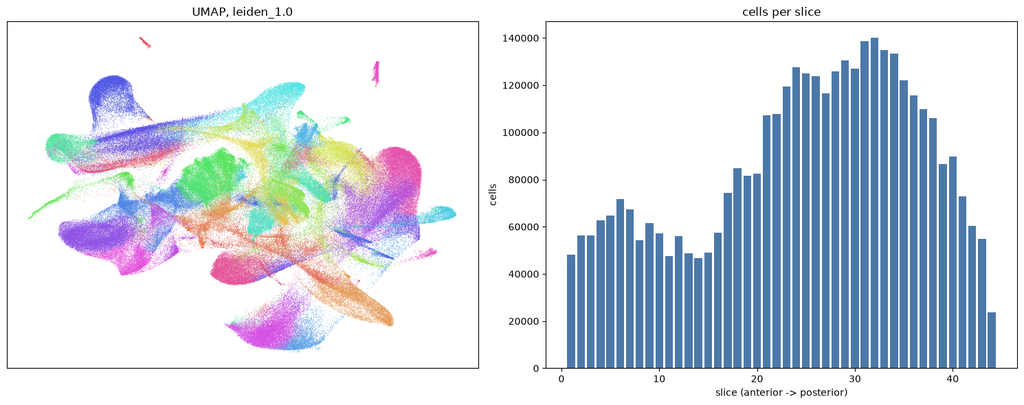

## 3. Drop the slice that does not align

One slice is left out of the 3D stack: it is a small fragment at the end of the series that barely overlaps its neighbor and has poor clusters. Its position in the stack is left empty, so the remaining slices keep their true spacing.

```python
keep = (~obs["slice"].isin(DROP_SLICES) & ~obs["extra_tissue_piece"]).to_numpy()

cells = ad.AnnData(obs=obs.loc[keep, [CLUSTER_KEY, "slice"]].copy())
cells.obs["slice_order"] = cells.obs["slice"].astype(int).to_numpy()
cells.obsm["spatial"] = spatial_um[keep]          # Xenium positions are already in um
slice_ids = sorted(cells.obs["slice_order"].unique())
print(f"{cells.n_obs:,} of {len(obs):,} cells kept, {len(slice_ids)} slices")
```

```
3,787,366 of 3,828,568 cells kept, 43 slices
```

## 4. Align, stage 1: cluster centroids + Procrustes

`dega.align.calc_landmarks` gives one landmark per (slice, cluster) at the cluster's centroid. A tissue-center landmark is added per slice. `calc_alignment_transform` then fits a rigid transform for each slice to its neighbors (within `alignment_window` slices), chain-walking out from the middle slice. Because the same cluster appears in neighboring slices, its centroid is a landmark that should land on top of itself after alignment.

```python
landmarks = dega.align.calc_landmarks(cells, cluster_key=CLUSTER_KEY, slice_attr="slice_order")

rows = []
for s in slice_ids:
    xy = cells.obsm["spatial"][cells.obs["slice_order"].to_numpy() == s]
    (x_lo, x_hi), (y_lo, y_hi) = np.percentile(xy[:, 0], [1, 99]), np.percentile(xy[:, 1], [1, 99])
    rows.append({"slice_order": s, "label": "tissue_center", "x": (x_lo + x_hi) / 2,
                 "y": (y_lo + y_hi) / 2, "count": np.nan, "source": "manual"})
landmarks = pd.concat([landmarks, pd.DataFrame(rows)], ignore_index=True)
landmarks.to_parquet(OUT_DIR / "centroid_landmarks.parquet")

procrustes = dega.align.calc_alignment_transform(
    landmarks, slice_attr="slice_order", reference=len(slice_ids) // 2, method="procrustes", **PROCRUSTES_KW,
)
procrustes.save(OUT_DIR / "procrustes_transform")
print(f"{len(landmarks):,} landmarks, reference slice index {procrustes.reference}")
```

```
1,278 landmarks, reference slice index 22
```

## 5. Align, stage 2: neighborhood overlap

A *neighborhood* is the alpha shape of all cells of one cluster in one slice, computed in each slice's native frame. `neighborhood_alignment` starts from the Procrustes pose and nudges each slice (a bounded rotation and translation) to maximize the overlap of matching neighborhoods in nearby slices. It returns the combined transform, which is applied to native coordinates.

```python
%%time
shapes = dega.nbhd.alpha_shape_cell_clusters_by_slice(
    cells, cluster_attr=CLUSTER_KEY, slice_attr="slice_order", z_attr=None, alphas=(ALPHA_UM,), progress_every=10,
)
print(f"{len(shapes)} neighborhoods across {shapes['slice_id'].nunique()} slices")
```

```
alpha shapes: slice 10/43 (10)
```

```
alpha shapes: slice 20/43 (28)
```

```
alpha shapes: slice 30/43 (38)
```

```
alpha shapes: slice 40/43 (19)
```

```
alpha shapes: done, 976 neighborhoods across 43 slices
976 neighborhoods across 43 slices
CPU times: user 2min 35s, sys: 961 ms, total: 2min 36s
Wall time: 2min 36s
```

```python
%%time
neighborhood = dega.align.neighborhood_alignment(
    shapes, procrustes, slice_attr="slice_id", cluster_attr="cluster_id", progress_every=20, **NBHD_KW,
)
neighborhood.save(OUT_DIR / "neighborhood_transform")
```

```
[neighborhood_alignment +   0.0s] phase 1: chain-walk over 43 slices (window=4)
[neighborhood_alignment +  49.6s] 20 slice-optimizations
[neighborhood_alignment + 134.9s] 40 slice-optimizations
[neighborhood_alignment + 143.0s] phase 2: sweep 1/4
[neighborhood_alignment + 171.9s] 60 slice-optimizations
[neighborhood_alignment + 245.0s] 80 slice-optimizations
[neighborhood_alignment + 295.9s] 100 slice-optimizations
[neighborhood_alignment + 350.1s] 120 slice-optimizations
[neighborhood_alignment + 361.8s] phase 2: sweep 2/4
[neighborhood_alignment + 383.4s] 140 slice-optimizations
[neighborhood_alignment + 449.5s] 160 slice-optimizations
[neighborhood_alignment + 493.4s] 180 slice-optimizations
[neighborhood_alignment + 555.6s] 200 slice-optimizations
[neighborhood_alignment + 574.1s] phase 2: sweep 3/4
[neighborhood_alignment + 589.4s] 220 slice-optimizations
[neighborhood_alignment + 647.7s] 240 slice-optimizations
[neighborhood_alignment + 692.8s] 260 slice-optimizations
[neighborhood_alignment + 762.7s] 280 slice-optimizations
[neighborhood_alignment + 787.1s] phase 2: sweep 4/4
[neighborhood_alignment + 794.9s] 300 slice-optimizations
[neighborhood_alignment + 845.0s] 320 slice-optimizations
[neighborhood_alignment + 896.7s] 340 slice-optimizations
[neighborhood_alignment + 964.7s] 360 slice-optimizations
[neighborhood_alignment + 999.3s] optimization complete
CPU times: user 16min 44s, sys: 362 ms, total: 16min 44s
Wall time: 17min 12s
```

## 6. Did the second stage help?

For each pair of adjacent slices: the mean over clusters of the intersection-over-union (IoU) of the two slices' alpha shapes after alignment. Higher means matching regions overlap better.

```python
native = _load_slice_geometries(shapes, "slice_id", "cluster_id", None)
alignments = {"centroids": procrustes.transforms, "neighborhood": neighborhood.transforms}


def adjacent_iou(transforms):
    out = []
    for a, b in zip(slice_ids[:-1], slice_ids[1:]):
        ious = []
        for cl in set(native[a]) & set(native[b]):
            ga = shapely.transform(native[a][cl], transforms[a].apply)
            gb = shapely.transform(native[b][cl], transforms[b].apply)
            inter = ga.intersection(gb).area
            union = ga.area + gb.area - inter
            ious.append(inter / union if union > 0 else 0.0)
        out.append(np.mean(ious) if ious else np.nan)
    return out


iou = pd.DataFrame({"slice": slice_ids[:-1]})
for name, t in alignments.items():
    iou[name] = adjacent_iou(t)
iou.to_csv(OUT_DIR / "adjacent_iou.csv", index=False)

fig, ax = plt.subplots(figsize=(11, 3.5))
ax.plot(iou["slice"], iou["centroids"], "o-", ms=3, label="centroids (Procrustes)")
ax.plot(iou["slice"], iou["neighborhood"], "o-", ms=3, label="+ neighborhood overlap")
ax.set(xlabel="slice (IoU with the next slice)", ylabel="mean cluster IoU", ylim=(0, 1))
ax.legend(frameon=False)
plt.tight_layout()
plt.show()
iou[["centroids", "neighborhood"]].mean().round(3)
```

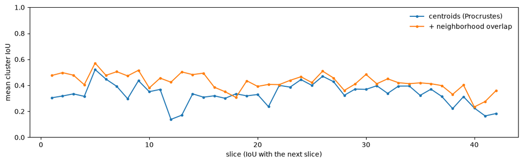

```
centroids       0.336
neighborhood    0.426
dtype: float64
```

## 7. Apply both alignments to every cell

The position along the stack is `(slice - reference) * 100 µm`, so the dropped slice leaves a gap instead of shifting the later slices.

```python
xy_native = cells.obsm["spatial"]
slices = cells.obs["slice_order"].to_numpy()
stack_um = (slices - procrustes.reference) * Z_SPACING_UM

aligned_xy = {}
for name, transforms in alignments.items():
    xy = np.empty_like(xy_native)
    for s in slice_ids:
        m = slices == s
        xy[m] = transforms[s].apply(xy_native[m])
    aligned_xy[name] = xy

aligned = pd.DataFrame({"slice_order": slices, "stack_um": stack_um}, index=cells.obs_names)
for name, xy in aligned_xy.items():
    aligned[f"x_{name}_um"], aligned[f"y_{name}_um"] = xy[:, 0], xy[:, 1]
aligned.to_parquet(OUT_DIR / "aligned_cells.parquet")

point_colors = cells.obs[CLUSTER_KEY].map(colors).to_numpy()
fig, axes = plt.subplots(2, 2, figsize=(16, 12))
for row, (name, xy) in enumerate(aligned_xy.items()):
    axes[row, 0].scatter(xy[:, 0], xy[:, 1], c=point_colors, s=0.02, linewidths=0, rasterized=True)
    axes[row, 0].set(title=f"{name}: all slices, looking along the stack", aspect="equal")
    axes[row, 0].invert_yaxis()
    axes[row, 1].scatter(stack_um, xy[:, 1], c=point_colors, s=0.02, linewidths=0, rasterized=True)
    axes[row, 1].set(title=f"{name}: side view", xlabel="stack (um)")
    axes[row, 1].invert_yaxis()
plt.tight_layout()
plt.show()
```

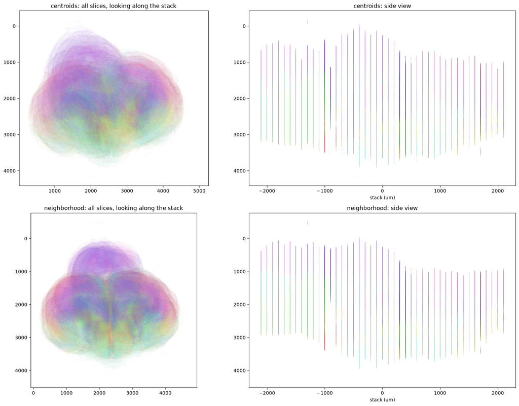

## 8. Write the CellCloud DegaFiles

`CellCloud` is a 3D point cloud of every cell. Its orbit camera always spins around the vertical (data-Z) axis, so `side_view_coords` puts the stack along data-X (anterior on the left, posterior on the right) and the dorsal-ventral axis along Z (dorsal up). Left-right drag then swings the brain around to its front and back.

**Draw order.** CellCloud draws points in file order and does not depth-sort them, so whatever is written last is painted on top. The initial camera of `2.0_Viz_CellCloud` (`rotation_x=20`, `rotation_orbit=-25`) sits on the posterior side, so the cells are written **anterior first, posterior last**: the slices nearest the camera cover the ones behind them. Orbiting to the other side shows the stack the wrong way round until the order is reversed.

Both alignments are written as named variants of one directory (`neighborhood` is the default; `centroids` can be switched to), together with the counts of all 480 genes.

```python
if CELL_CLOUD_DIR.exists():
    shutil.rmtree(CELL_CLOUD_DIR)

draw_order = np.argsort(slices, kind="stable")        # posterior slices last, on top for the posterior camera
for name in ["neighborhood", "centroids"]:
    xyz = side_view_coords(aligned_xy[name], stack_um)[draw_order]
    a = ad.AnnData(obs=cells.obs.iloc[draw_order][[CLUSTER_KEY]].copy())
    a.obs["Z"] = xyz[:, 2]
    a.obsm["spatial"] = xyz[:, :2]
    a.uns[f"{CLUSTER_KEY}_colors"] = [colors[c] for c in a.obs[CLUSTER_KEY].cat.categories]
    dega.align.write_alignment_point_cloud(
        a, CELL_CLOUD_DIR, alignment_name=name, z_key="Z", cluster_key=CLUSTER_KEY, write_genes=False, overwrite=True,
    )
    print(f"wrote alignment '{name}'")
```

```
Clustering data saved to /home/jovyan/workbench/Xenium_E15.5_Celldega_Docs/DegaFiles/xenium_E15.5_cell_cloud/cell_clusters
wrote alignment 'neighborhood'
wrote alignment 'centroids'
```

```python
%%time
meta_gene = write_point_cloud_genes(CLUSTERED_H5AD, CELL_CLOUD_DIR, keep_mask=keep)
meta_gene.sort_values("mean", ascending=False).head()
```

```
  scanned 250,000/3,828,568 cells (17s)
  scanned 500,000/3,828,568 cells (19s)
  scanned 750,000/3,828,568 cells (20s)
  scanned 1,000,000/3,828,568 cells (21s)
  scanned 1,250,000/3,828,568 cells (23s)
  scanned 1,500,000/3,828,568 cells (24s)
  scanned 1,750,000/3,828,568 cells (26s)
  scanned 2,000,000/3,828,568 cells (27s)
  scanned 2,250,000/3,828,568 cells (29s)
  scanned 2,500,000/3,828,568 cells (30s)
  scanned 2,750,000/3,828,568 cells (31s)
  scanned 3,000,000/3,828,568 cells (33s)
  scanned 3,250,000/3,828,568 cells (35s)
  scanned 3,500,000/3,828,568 cells (36s)
  scanned 3,750,000/3,828,568 cells (38s)
  scanned 3,828,568/3,828,568 cells (38s)
480 genes written, 454s total
CPU times: user 51.6 s, sys: 14 s, total: 1min 5s
Wall time: 7min 34s
```

|  | mean | std | max | non-zero | color |
| --- | --- | --- | --- | --- | --- |
| Dcx | 12.074173 | 10.324595 | 187.0 | 0.900086 | #e5df50 |
| Nfib | 11.549628 | 15.915588 | 455.0 | 0.773084 | #50d4e5 |
| Id4 | 10.681563 | 14.054515 | 444.0 | 0.814434 | #50e55d |
| Foxg1 | 10.390632 | 14.142993 | 253.0 | 0.558333 | #93e550 |
| Vim | 8.388807 | 13.465835 | 492.0 | 0.770488 | #e5506e |